# Linear mixed model analysis of the helpfulness of features of online product reviews

## Section 1

### Introduction

In this study, we examined the features of online reviews to determine which were helpful to customers. The two hypotheses were: identity disclosure and review extremity are positively related to helpfulness. Hence, the 3 independent variables were identity disclosure with 2 levels (anonymous vs identified); extremity with 2 levels (high vs low); and product type with two levels (search vs experience). Disclosure was manipulated between subjects while extremity and product type were manipulated within subjects. The dependent variable was participants’ rating on a 0-10 scale. To investigate this, a linear mixed model analysis with crossed random effects for participants and product was implemented with the maximal random effects structure justified by design. This included by participant random intercepts and by participant random slopes for product type and extremity and their interaction, and by product random intercepts and by extremity and disclosure random slopes and their interaction. The Satterthwaite and Bonferroni-Holm methods were used to control for Type I errors for fitting the mixed models and multiple comparisons for the follow-up analyses.

### Summary

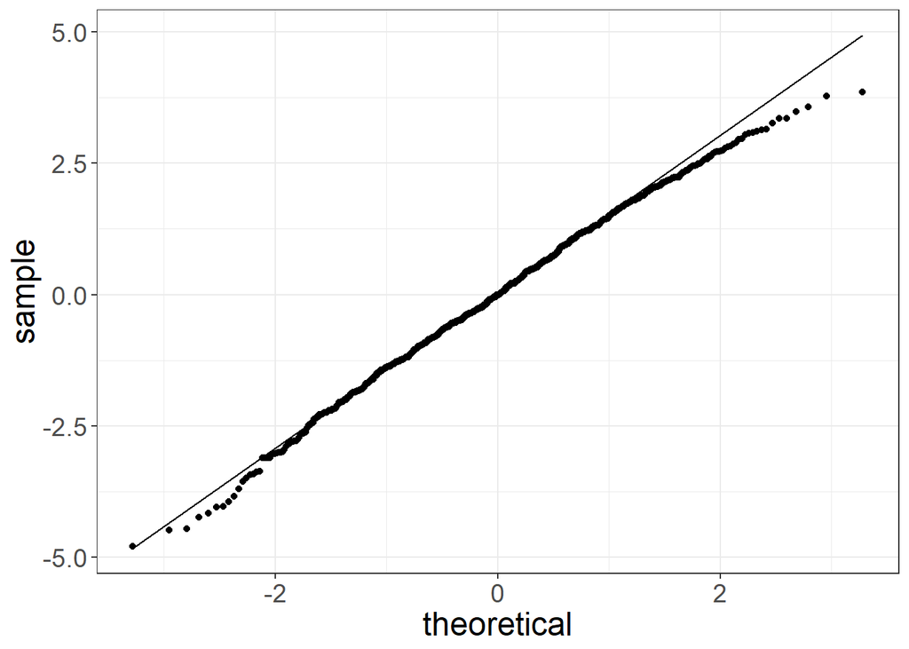

*Fig 1.* Quantile-quantile plot of the theoretical distribution against the distribution from the maximal mixed model.

The final model showed a significant main effect of extremity *F*(1, 40.66) = 5.88, *p* < 0.05 and disclosure *F*(1, 38.10) = 7.93, *p* < 0.01. The two-way interactions between product type and extremity *F*(1, 24.26) = 27.24, *p* < 0.0001 and product type and disclosure were also significant *F*(1, 30.86) = 4.54, *p* < 0.05.

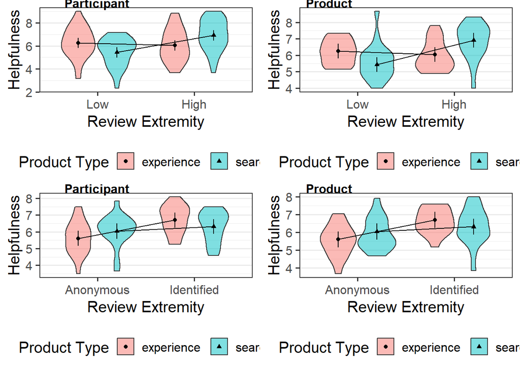

*Fig 2.* Helpfulness by review rating extremity and identity disclosure by grouping factors participant and product.

Examining figure 2, it appears that the helpfulness of reviews with high and low extremity vary by product type; while reviews with a unique name and picture are more helpful for experience products than search products.

#### Hypothesis 1: Disclosure of identity on helpfulness

Follow-up analyses concurred with the two hypotheses in the beginning - identity disclosure and review extremity were positively related to helpfulness. However, this effect was modulated by the type of product that the review was made on. Reviews with identified reviewers were rated significantly more helpful (*M* = 6.70, *SE* = 0.23) than anonymous reviews (*M* = 5.61, *SE* = 0.23) for experience products (*t*(55.3) = -3.52, *p* < 0.001). There was no significant effect of disclosure on helpfulness for search products (*p*> 0.05). This suggests that consumers value reviews of other consumers who have engaged with the product they were interested in when evaluating product quality has to be a personal experience. Reviews with a unique name and picture help in identifying a reviewer as another consumer, leading to a higher helpfulness rating.

#### Hypothesis 2: Review rating extremity on helpfulness

Reviews with extreme ratings (i.e. 1 or 5 stars) were rated as significantly more helpful (*M* = 6.92, *SE* = 0.23) than reviews with non-extreme ratings of 2, 3 and 4 stars (*M* = 5.44, *SE* = 0.23) for search products. There was no significant effect of review rating extremity for experience products (*p*> 0.05). This suggests that consumers interested in products where information is easily acquired and compared prefer reviews that are extreme to help them differentiate between similar products.

## Section 2

```r
library("tidyverse")
library("afex")
library("emmeans")
library("cowplot")
theme_set(theme_bw(base_size = 15) +
            theme(legend.position="bottom",
                  panel.grid.major.x = element_blank(),
                  panel.grid.minor.x = element_blank()))
options(digits = 3)
```

```r
# Setting up and preparing
helpf <- read_csv("helpfulness.csv")

helpf <- helpf %>%
  mutate(product_type = factor(product_type,
                         levels = c("experience",
                                    "search")),
         extremity = factor(extremity,
                          levels = c("low", "high")),
         disclosure = factor(disclosure,
                             levels = c("anonymous", "identified")),
         participant = factor(participant),
         product = factor(product))

str(helpf)
```

```
## Classes 'tbl_df', 'tbl' and 'data.frame':    960 obs. of  6 variables:
##  $ participant : Factor w/ 40 levels "1","2","3","4",..: 1 1 1 1 1 1 1 1 1 1 ...
##  $ product_type: Factor w/ 2 levels "experience","search": 1 1 1 1 1 1 1 1 1 1 ...
##  $ extremity   : Factor w/ 2 levels "low","high": 2 2 2 1 1 1 2 2 2 1 ...
##  $ disclosure  : Factor w/ 2 levels "anonymous","identified": 1 1 1 1 1 1 1 1 1 1 ...
##  $ product     : Factor w/ 39 levels "1","2","3","4",..: 21 21 21 21 21 21 22 22 22 22 ...
##  $ helpfulness : num  3 7 4 8 7 7 8 3 7 8 ...
```

```r
# returns an array of rows and cols with missing data
which(is.na(helpf), arr.ind=T) # no missing data
```

```
##      row col
```

```r
# maximal random effects structure with singular fit
maximal <- mixed(helpfulness ~ product_type * extremity * disclosure +
                   (product_type * extremity|participant) +
                   (extremity * disclosure|product), data = helpf,
                 method = "S")
```

```
## Fitting one lmer() model. [DONE]
## Calculating p-values. [DONE]
```

```r
summary(maximal)$varcor
```

```
##  Groups      Name                     Std.Dev. Corr
##  participant (Intercept)              0.611
##              product_type1            0.386     0.01
##              extremity1               0.705    -0.28 -0.06
##              product_type1:extremity1 0.240     0.29  0.15 -0.08
##  product     (Intercept)              0.388
##              extremity1               0.288     0.34
##              disclosure1              0.310     0.31  0.89
##              extremity1:disclosure1   0.267    -0.77  0.17 -0.05
##  Residual                             1.567
```

```r
maximal
```

```
## Mixed Model Anova Table (Type 3 tests, S-method)
##
## Model: helpfulness ~ product_type * extremity * disclosure + (product_type *
## Model:     extremity | participant) + (extremity * disclosure | product)
## Data: helpf
##                              Effect       df         F p.value
## 1                      product_type 1, 37.27      0.25     .62
## 2                         extremity 1, 39.21    6.07 *     .02
## 3                        disclosure 1, 37.89   7.55 **    .009
## 4            product_type:extremity 1, 24.56 27.67 ***  <.0001
## 5           product_type:disclosure 1, 32.49    5.11 *     .03
## 6              extremity:disclosure 1, 39.58      0.17     .68
## 7 product_type:extremity:disclosure 1, 21.96      0.08     .78
## ---
## Signif. codes:  0 '***' 0.001 '**' 0.01 '*' 0.05 '+' 0.1 ' ' 1
```

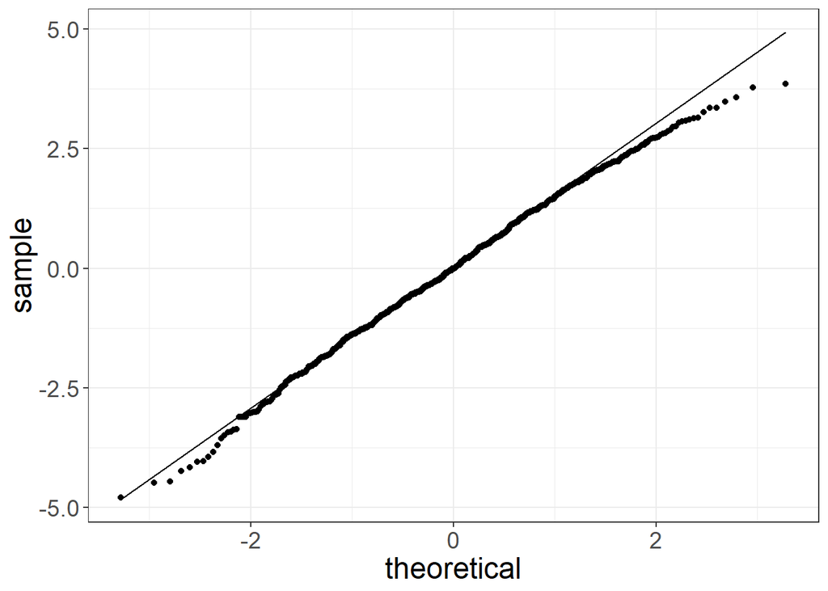

```r
# plotting residuals
helpf$residuals <- residuals(maximal$full_model)
ggplot(helpf, aes(sample = residuals)) +
  stat_qq() +
  stat_qq_line() +
  theme_bw() +
  theme(text = element_text(size = 18))
```

```r
# removing product correlation removes singular fit warning
reduced1 <- mixed(helpfulness ~ product_type * extremity * disclosure +
                   (product_type * extremity|participant) +
                   (extremity * disclosure||product), helpf,
                 method = "S", expand_re = TRUE)
```

```
## Fitting one lmer() model. [DONE]
## Calculating p-values. [DONE]
```

```r
summary(reduced1)$varcor
```

```
##  Groups      Name                            Std.Dev. Corr
##  participant (Intercept)                     0.614
##              re1.product_type1               0.384    -0.03
##              re1.extremity1                  0.675    -0.25 -0.09
##              re1.product_type1_by_extremity1 0.214     0.16  0.26 -0.03
##  product     (Intercept)                     0.372
##  product.1   re2.extremity1                  0.294
##  product.2   re2.disclosure1                 0.291
##  product.3   re2.extremity1_by_disclosure1   0.307
##  Residual                                    1.568
```

```r
reduced1
```

```
## Mixed Model Anova Table (Type 3 tests, S-method)
##
## Model: helpfulness ~ product_type * extremity * disclosure + (product_type *
## Model:     extremity | participant) + (extremity * disclosure || product)
## Data: helpf
##                              Effect       df         F p.value
## 1                      product_type 1, 37.82      0.02     .90
## 2                         extremity 1, 40.42    5.89 *     .02
## 3                        disclosure 1, 37.85   7.84 **    .008
## 4            product_type:extremity 1, 23.87 27.87 ***  <.0001
## 5           product_type:disclosure 1, 30.97    4.54 *     .04
## 6              extremity:disclosure 1, 40.11      0.17     .68
## 7 product_type:extremity:disclosure 1, 20.85      0.07     .79
## ---
## Signif. codes:  0 '***' 0.001 '**' 0.01 '*' 0.05 '+' 0.1 ' ' 1
```

```r
# removing participant correlation retains the singular fit warning
reduced2 <- mixed(helpfulness ~ product_type * extremity * disclosure +
                   (product_type * extremity||participant) +
                   (extremity * disclosure|product), helpf,
                 method = "S", expand_re = TRUE)
```

```
## Fitting one lmer() model. [DONE]
## Calculating p-values. [DONE]
```

```r
summary(reduced2)$varcor
```

```
##  Groups        Name                            Std.Dev. Corr
##  participant   (Intercept)                     0.613
##  participant.1 re1.product_type1               0.388
##  participant.2 re1.extremity1                  0.703
##  participant.3 re1.product_type1_by_extremity1 0.242
##  product       (Intercept)                     0.389
##                re2.extremity1                  0.291     0.35
##                re2.disclosure1                 0.308     0.29  0.81
##                re2.extremity1_by_disclosure1   0.274    -0.74  0.21 -0.10
##  Residual                                      1.565
```

```r
reduced2
```

```
## Mixed Model Anova Table (Type 3 tests, S-method)
##
## Model: helpfulness ~ product_type * extremity * disclosure + (product_type *
## Model:     extremity || participant) + (extremity * disclosure | product)
## Data: helpf
##                              Effect       df         F p.value
## 1                      product_type 1, 37.01      0.23     .64
## 2                         extremity 1, 39.38    6.00 *     .02
## 3                        disclosure 1, 37.83   7.72 **    .008
## 4            product_type:extremity 1, 24.57 27.37 ***  <.0001
## 5           product_type:disclosure 1, 31.69    5.23 *     .03
## 6              extremity:disclosure 1, 39.70      0.17     .69
## 7 product_type:extremity:disclosure 1, 22.12      0.08     .78
## ---
## Signif. codes:  0 '***' 0.001 '**' 0.01 '*' 0.05 '+' 0.1 ' ' 1
```

```r
# removing both correlations removes singular fit warning again
reduced3 <- mixed(helpfulness ~ product_type * extremity * disclosure +
                    (product_type * extremity||participant) +
                    (extremity * disclosure||product), helpf,
                  method = "S", expand_re = TRUE)
```

```
## Fitting one lmer() model. [DONE]
## Calculating p-values. [DONE]
```

```r
summary(reduced3)$varcor
```

```
##  Groups        Name                            Std.Dev.
##  participant   (Intercept)                     0.613
##  participant.1 re1.product_type1               0.386
##  participant.2 re1.extremity1                  0.674
##  participant.3 re1.product_type1_by_extremity1 0.216
##  product       (Intercept)                     0.375
##  product.1     re2.extremity1                  0.299
##  product.2     re2.disclosure1                 0.291
##  product.3     re2.extremity1_by_disclosure1   0.310
##  Residual                                      1.567
```

```r
reduced3
```

```
## Mixed Model Anova Table (Type 3 tests, S-method)
##
## Model: helpfulness ~ product_type * extremity * disclosure + (product_type *
## Model:     extremity || participant) + (extremity * disclosure || product)
## Data: helpf
##                              Effect       df         F p.value
## 1                      product_type 1, 37.65      0.02     .90
## 2                         extremity 1, 40.66    5.88 *     .02
## 3                        disclosure 1, 38.10   7.93 **    .008
## 4            product_type:extremity 1, 24.26 27.24 ***  <.0001
## 5           product_type:disclosure 1, 30.86    4.54 *     .04
## 6              extremity:disclosure 1, 40.52      0.17     .68
## 7 product_type:extremity:disclosure 1, 21.05      0.07     .79
## ---
## Signif. codes:  0 '***' 0.001 '**' 0.01 '*' 0.05 '+' 0.1 ' ' 1
```

```r
# further removing extremity-disclosure interaction
reduced4 <- mixed(helpfulness ~ product_type * extremity * disclosure +
                    (product_type * extremity||participant) +
                    (extremity + disclosure||product), helpf,
                  method = "S", expand_re = TRUE)
```

```
## Fitting one lmer() model. [DONE]
## Calculating p-values. [DONE]
```

```r
summary(reduced4)$varcor
```

```
##  Groups        Name                            Std.Dev.
##  participant   (Intercept)                     0.611
##  participant.1 re1.product_type1               0.384
##  participant.2 re1.extremity1                  0.695
##  participant.3 re1.product_type1_by_extremity1 0.238
##  product       (Intercept)                     0.373
##  product.1     re2.extremity1                  0.354
##  product.2     re2.disclosure1                 0.287
##  Residual                                      1.578
```

```r
reduced4
```

```
## Mixed Model Anova Table (Type 3 tests, S-method)
##
## Model: helpfulness ~ product_type * extremity * disclosure + (product_type *
## Model:     extremity || participant) + (extremity + disclosure || product)
## Data: helpf
##                              Effect       df         F p.value
## 1                      product_type 1, 37.52      0.02     .90
## 2                         extremity 1, 40.38    5.18 *     .03
## 3                        disclosure 1, 37.88   7.95 **    .008
## 4            product_type:extremity 1, 25.53 23.54 ***  <.0001
## 5           product_type:disclosure 1, 30.61    4.58 *     .04
## 6              extremity:disclosure 1, 37.41      0.43     .52
## 7 product_type:extremity:disclosure 1, 38.20      0.87     .36
## ---
## Signif. codes:  0 '***' 0.001 '**' 0.01 '*' 0.05 '+' 0.1 ' ' 1
```

```r
# further removing producttype-extremity interaction
reduced5 <- mixed(helpfulness ~ product_type * extremity * disclosure +
                    (product_type + extremity||participant) +
                    (extremity * disclosure||product), helpf,
                  method = "S", expand_re = TRUE)
```

```
## Fitting one lmer() model. [DONE]
## Calculating p-values. [DONE]
```

```r
summary(reduced5)$varcor
```

```
##  Groups        Name                          Std.Dev.
##  participant   (Intercept)                   0.611
##  participant.1 re1.product_type1             0.384
##  participant.2 re1.extremity1                0.673
##  product       (Intercept)                   0.373
##  product.1     re2.extremity1                0.307
##  product.2     re2.disclosure1               0.287
##  product.3     re2.extremity1_by_disclosure1 0.330
##  Residual                                    1.578
```

```r
reduced5
```

```
## Mixed Model Anova Table (Type 3 tests, S-method)
##
## Model: helpfulness ~ product_type * extremity * disclosure + (product_type +
## Model:     extremity || participant) + (extremity * disclosure || product)
## Data: helpf
##                              Effect       df         F p.value
## 1                      product_type 1, 37.52      0.02     .90
## 2                         extremity 1, 41.79    5.82 *     .02
## 3                        disclosure 1, 37.89   7.95 **    .008
## 4            product_type:extremity 1, 23.95 32.16 ***  <.0001
## 5           product_type:disclosure 1, 30.61    4.58 *     .04
## 6              extremity:disclosure 1, 41.78      0.18     .67
## 7 product_type:extremity:disclosure 1, 19.01      0.05     .83
## ---
## Signif. codes:  0 '***' 0.001 '**' 0.01 '*' 0.05 '+' 0.1 ' ' 1
```

```r
# further removing all interactions
reduced6 <- mixed(helpfulness ~ product_type * extremity * disclosure +
                    (product_type + extremity||participant) +
                    (extremity + disclosure||product), helpf,
                  method = "S", expand_re = TRUE)
```

```
## Fitting one lmer() model. [DONE]
## Calculating p-values. [DONE]
```

```r
summary(reduced6)$varcor
```

```
##  Groups        Name              Std.Dev.
##  participant   (Intercept)       0.610
##  participant.1 re1.product_type1 0.382
##  participant.2 re1.extremity1    0.697
##  product       (Intercept)       0.370
##  product.1     re2.extremity1    0.362
##  product.2     re2.disclosure1   0.281
##  Residual                        1.596
```

```r
reduced6
```

```
## Mixed Model Anova Table (Type 3 tests, S-method)
##
## Model: helpfulness ~ product_type * extremity * disclosure + (product_type +
## Model:     extremity || participant) + (extremity + disclosure || product)
## Data: helpf
##                              Effect        df         F p.value
## 1                      product_type  1, 37.31      0.02     .90
## 2                         extremity  1, 41.09    5.11 *     .03
## 3                        disclosure  1, 37.56   7.97 **    .008
## 4            product_type:extremity  1, 23.16 27.72 ***  <.0001
## 5           product_type:disclosure  1, 30.24    4.64 *     .04
## 6              extremity:disclosure  1, 37.34      0.46     .50
## 7 product_type:extremity:disclosure 1, 688.42      1.28     .26
## ---
## Signif. codes:  0 '***' 0.001 '**' 0.01 '*' 0.05 '+' 0.1 ' ' 1
```

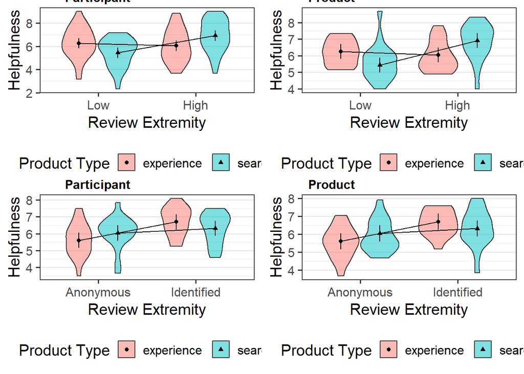

```r
# looking at the data
plot_grid(
  afex_plot(reduced3, x = "extremity", trace = "product_type", random = "participant",
            dodge = 0.8,
            data_geom = geom_violin,
            data_arg = list(width = 0.8),
            mapping = c("fill", "shape"),
            factor_levels = list(extremity = c("Low", "High")),
            legend_title = "Product Type") +
    labs(x = "Review Extremity", y = "Helpfulness"),
  afex_plot(reduced3, x = "extremity", trace = "product_type", random = "product",
            dodge = 0.8,
            data_geom = geom_violin,
            data_arg = list(width = 0.8),
            mapping = c("fill", "shape"),
            factor_levels = list(extremity = c("Low", "High")),
            legend_title = "Product Type") +
    labs(x = "Review Extremity", y = "Helpfulness"),
  afex_plot(reduced3, x = "disclosure", trace = "product_type", random = "participant",
            dodge = 0.8,
            data_geom = geom_violin,
            data_arg = list(width = 0.8),
            mapping = c("fill", "shape"),
            factor_levels = list(disclosure = c("Anonymous", "Identified")),
            legend_title = "Product Type") +
    labs(x = "Review Extremity", y = "Helpfulness"),
  afex_plot(reduced3, x = "disclosure", trace = "product_type", random = "product",
            dodge = 0.8,
            data_geom = geom_violin,
            data_arg = list(width = 0.8),
            mapping = c("fill", "shape"),
            factor_levels = list(disclosure = c("Anonymous", "Identified")),
            legend_title = "Product Type") +
    labs(x = "Review Extremity", y = "Helpfulness"),
  labels = c("Participant", "Product", "Participant", "Product"),
  ncol = 2, label_size = 12, vjust = 0.2, hjust = -1)
```

```r
# further analysis using emmeans
emmeans(reduced3, "extremity", by = "product_type")
```

```
## product_type = experience:
##  extremity emmean    SE  df lower.CL upper.CL
##  low         6.26 0.225 108     5.82     6.71
##  high        6.04 0.225 108     5.60     6.49
##
## product_type = search:
##  extremity emmean    SE  df lower.CL upper.CL
##  low         5.44 0.225 111     4.99     5.89
##  high        6.92 0.225 111     6.47     7.36
##
## Results are averaged over the levels of: disclosure
## Degrees-of-freedom method: kenward-roger
## Confidence level used: 0.95
```

```r
pairs(emmeans(reduced3, "extremity", by = "product_type"), adjust = "holm")
```

```
## product_type = experience:
##  contrast   estimate    SE   df t.ratio p.value
##  low - high     0.22 0.307 52.1   0.717  0.4766
##
## product_type = search:
##  contrast   estimate    SE   df t.ratio p.value
##  low - high    -1.48 0.307 53.2  -4.806  <.0001
##
## Results are averaged over the levels of: disclosure
```

```r
emmeans(reduced3, "disclosure", by = "product_type")
```

```
## product_type = experience:
##  disclosure emmean    SE   df lower.CL upper.CL
##  anonymous    5.61 0.225 77.9     5.16     6.05
##  identified   6.70 0.227 77.4     6.25     7.15
##
## product_type = search:
##  disclosure emmean    SE   df lower.CL upper.CL
##  anonymous    6.04 0.229 76.5     5.58     6.50
##  identified   6.32 0.223 79.3     5.87     6.76
##
## Results are averaged over the levels of: extremity
## Degrees-of-freedom method: kenward-roger
## Confidence level used: 0.95
```

```r
pairs(emmeans(reduced3, "disclosure", by = "product_type"), adjust = "holm")
```

```
## product_type = experience:
##  contrast               estimate    SE   df t.ratio p.value
##  anonymous - identified   -1.093 0.311 55.3  -3.515  0.0009
##
## product_type = search:
##  contrast               estimate    SE   df t.ratio p.value
##  anonymous - identified   -0.278 0.311 56.7  -0.892  0.3760
##
## Results are averaged over the levels of: extremity
```